# 대구 시민의 문화생활 알아보기

2020년 대구 시민 여가활동 통계 자료를 통해 대구 시민의 문화생활 실태와 만족도를 알아보고자 한다

공공데이터 출처

- [대구 D데이터허브](https://data.daegu.go.kr)
- [국가통계포털](https://kosis.kr)

분석 기준

- 구군별, 성별, 연령 등 세부 그룹별 데이터 추출이 아닌 전체 대구 시민을 기준으로 분석
- 전체 평균값과 일치하지 않아 '소계' 행의 데이터를 사용하지 않았음

인코딩

- utf-8 encoding 오류로 인해 cp949로 인코딩
- UnicodeDecodeError: 'utf-8' codec can't decode byte 0xb1 in position 1: invalid start byte

```python
import pandas as pd
import numpy as np
import matplotlib.pyplot as plt
from matplotlib import font_manager as fm, rc
%matplotlib inline


font_path = './font/malgun.ttf'
font_name = fm.FontProperties(fname=font_path).get_name()
rc('font', family=font_name)
```

파일명

- 평균 여가활동 시간: avg_activity_time
- 주말이나 휴일의 여가활동: holiday_activity
- 문화체육시설 이용 만족도: feedback
- 문화예술시설 이용률: occupancy_ration
- 여가활동 만족도 및 불만 이유: activiti_survey
- 필요한 문화예술시설: needs

```python
avg20 = pd.read_csv('./data/daegu/avg_activity_time_2020.csv',
                    skiprows=1, encoding='cp949')
hday20 = pd.read_csv('./data/daegu/holiday_activity_2020.csv',
                     skiprows=1, encoding='cp949')
fb20 = pd.read_csv('./data/daegu/feedback_2020.csv',
                   skiprows=1, encoding='cp949')
survey20 = pd.read_csv('./data/daegu/activity_survey_2020.csv',
                       skiprows=1, encoding='cp949')
ratio20 = pd.read_csv('./data/daegu/occupancy_ratio_2020.csv',
                      skiprows=1,encoding='cp949')
needs20 = pd.read_csv('./data/daegu/needs_2020.csv',
                      skiprows=1, encoding='cp949')
```

## 1. 대구 시민의 평균 여가활동 시간

- 평일, 토요일, 일요일, 1주 통계

```python
avg20 = avg20.iloc[0, 2:]
avg20 = avg20.rename(index={'한 주 당': '1주'})
avg20.name='시간'
```

## 2. 주말이나 휴일의 여가활동

- 여가활동 유형과 가장 많이 하는 활동 순위

1,2,3순위 복수응답 컬럼을 제외하고 str value '-'를 치환한 후 float type으로 변경

```python
hday20.iloc[0, 2:16]
htable = hday20.iloc[1:, 2:16]
htable.columns = hday20.iloc[0, 2:16]
htable = htable.replace('-', np.nan)
htable.fillna(0)
htable = htable.astype(float)
```

대구시 전체 소계 행을 인덱스와 함께 오름차순으로 정렬해서 DF객체로 생성

```python
activity_r = pd.DataFrame(htable.loc[1])
activity_r = activity_r.sort_values(by=1)
activity_r.columns = ['비율(단위: %)']
```

## 3. 문화체육시설 이용률과 만족도

- 문화체육시설 종류
- 대구 시민들은 문화시설을 얼마나 이용하는지
- 가장 많이 이용하는 문화체육시설

### 3-1. 문화체육시설의 종류

필요한 데이터 부분만 추출 후 데이터 정돈

```python
ratio20 = ratio20.iloc[:2, 2:].transpose()
```

```python
ratio20.columns = ['문화체육시설', '이용률(복수응답)']
ratio20['문화체육시설'][10] = '이용한적 없음'
ratio20 = ratio20.reset_index(drop=True)
```

### 3-2. 대구 시민들은 문화시설을 얼마나 활용하는지

```python
daegu_p = pd.read_excel('././././data/daegu/daegu_population_2020.xlsx',
                        dtype=str, na_filter=False)
daegu_p = int(daegu_p.iloc[5, 1])
```

```python
ratio20['이용률(복수응답)'] = ratio20['이용률(복수응답)'].astype(float)
rdf = pd.DataFrame({'인구(단위: 만명)': daegu_p,
                    '이용경험있음(단위: %)': 100-(ratio20['이용률(복수응답)'][10]),
                    '이용하지않음(단위: %)': ratio20['이용률(복수응답)'][10]},
                   index=[1])
```

### 3-3. 가장 많이 이용하는 문화시설

```python
r20tb = ratio20.iloc[:9, :].sort_values(by='이용률(복수응답)')
```

## 4. 여가활동 만족도와 불만족 사유

- 대구 문화시설 이용 만족도
- 불만족 이유 중 가장 높은 순위부터 집계

만족도 분포 행만을 추출 후 컬럼 설정 및 데이터 형변환

```python
fb20tb = fb20.iloc[:2, 3:]
fb20tb.columns=['만족', '보통', '불만족']
fb20tb = fb20tb.drop(0)
fb20tb = fb20tb.astype(float)
```

테이블에서 str value를 numpy nan값으로 치환 후 만족도 사유 컬럼만 뽑아서 방향 전환

```python
survey20 = survey20.replace('-', np.nan)
survey20 = survey20.iloc[:2, 2:]
survey20.iloc[1] = survey20.iloc[1].astype(float)
```

## 5. 필요한 문화체육시설

- 전체 시민을 기준으로 필요한 문화체육시설 순위
- 지역별 필요 시설 우선순위

### 5-1. 대구 시민 전체를 기준으로한 필요 문화체육시설 순위

```python
nrank = needs20.iloc[1:, 1:].describe().loc['mean']
nrank = nrank.sort_values(ascending=False)
nrank = list(nrank)
```

```python
nrank2 = pd.DataFrame(data={'순위': [1, 2, 3, 4, 5, 6, 7, 8, 9, 10],
                            '시설': ['체육시설 및 경기장', '복지관', '영화관',
                                   '공연장', '도서관', '문예회관·지역문화원',
                                   '야외음악당·박물관','미술관·화랑',
                                   '청소년수련시설', '기타'],
                            '평균': nrank})
```

### 5-2. 지역별 필요 우선순위

지역별 데이터 분리

```python
district = needs20.iloc[1:9, 1:]
district.set_index=('구분별(2)')
district = district.transpose()
district.columns = district.loc['구분별(2)']
district.drop('구분별(2)', inplace=True)
district = district.astype(float)
```

지역구별 문화시설 우선순위 인덱스 추출

```python
d_prior = []
for c in district.columns:
    d = district[c]
    d = d.sort_values(ascending=False)
    d = list(d.index)
    d_prior.append(d)
```

모든 지역구별 필요 시설 우선 순위 정보만을 DataFrame으로 구성

```python
dtable = pd.DataFrame(d_prior)
dtable = dtable.transpose()
dtable.columns=['중구', '동구', '서구', '남구',
                '북구', '수성구', '달서구', '달성군']
dtable.insert(0, '필요 순위', [1, 2, 3, 4, 5, 6, 7, 8, 9, 10])
```

# 대구 시민의 문화생활 만족도를 높이는 방안

대구 사람들의 문화생활 만족도 파악

문화생활 만족도를 높이는 방안

- 지역 내 문화시설을 알려서 이용을 유도
- 개인의 경제적, 시간적 요인을 해소

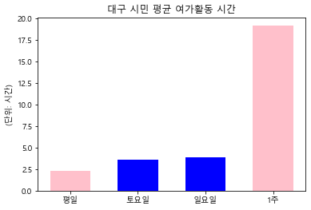

```python
plt.bar(avg20.index, avg20, color=['pink', 'b', 'b', 'pink'], width=0.6)
plt.title('대구 시민 평균 여가활동 시간')
plt.ylabel('(단위: 시간)')
plt.show()
```

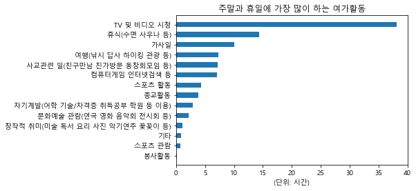

```python
index = np.arange(len(activity_r.index))
plt.barh(y=index, width=activity_r['비율(단위: %)'], height=0.5)
plt.title('주말과 휴일에 가장 많이 하는 여가활동')
plt.xlabel('(단위: 시간)')
plt.yticks(index, activity_r.index)
plt.show()
```

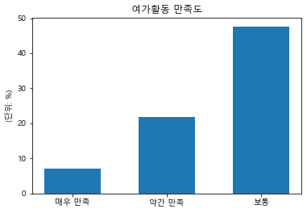

```python
plt.bar(survey20.iloc[0, :3], survey20.iloc[1, :3], width=0.6)
plt.title('여가활동 만족도')
plt.ylabel('(단위: %)')
plt.show()
```

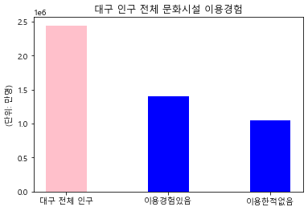

```python
plt.bar(['대구 전체 인구', '이용경험있음', '이용한적없음'], [rdf.iloc[0, 0], rdf.iloc[0, 0]*0.573, rdf.iloc[0, 0]*0.427], color=['pink', 'b', 'b'], width=0.4)
plt.title('대구 인구 전체 문화시설 이용경험')
plt.ylabel('(단위: 만명)')
plt.show()
```

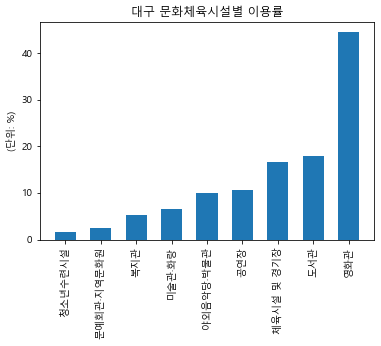

```python
plt.bar(r20tb['문화체육시설'], r20tb['이용률(복수응답)'], width=0.6)
plt.title('대구 문화체육시설별 이용률')
plt.ylabel('(단위: %)')
plt.xticks(rotation='vertical')
plt.show()
```

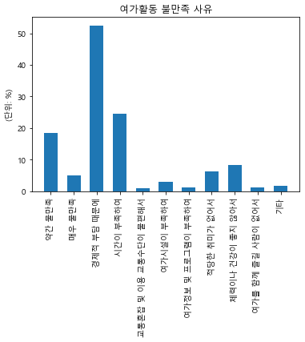

```python
plt.bar(survey20.iloc[0, 3:], survey20.iloc[1, 3:], width=0.6)
plt.title('여가활동 불만족 사유')
plt.ylabel('(단위: %)')
plt.xticks(rotation='vertical')
plt.show()
```

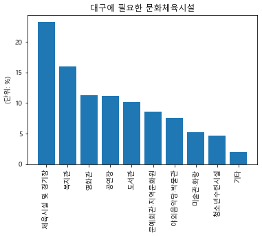

```python
plt.bar(nrank2['시설'], nrank2['평균'])
plt.title('대구에 필요한 문화체육시설')
plt.ylabel('(단위: %)')
plt.xticks(rotation='vertical')
plt.show()
```